# ABM

[figure not shown]

[figure not shown]

[figure not shown]

[figure not shown]

[figure not shown]

[figure not shown]

[figure not shown]

# Overview

#### KTH Royal Institute of Technology

### Total publications (fractionalized)

2919.7

### Field-normalized citations

1.13

### Share top 10% publications

11.0%

### Share top 20% journals

31.0%

### Co-publications with Swedish non-universities

20.0%

### International co-publications

71.0%

### Background

Statistics regarding citations and co-publishing are based on the subset of publications in DiVA that are registered in Web of Science.

### Further information

- [Guide to the Annual Bibliometric Monitoring at KTH](https://intra.kth.se/bibliometri/public/link/attachment/Guide%20to%20the%20Annual%20Bibliometric%20Monitoring%20at%20KTH.pdf)
- [Description of data, methods and indicators in KTH Annual Bibliometric Monitoring](https://intra.kth.se/bibliometri/public/link/attachment/Description%20of%20data,%20methods%20and%20indicators%20in%20KTH%20Annual%20Bibliometric%20Monitoring.pdf)
- [Formal definitions of field normalized citation indicators at KTH](https://www.kth.se/polopoly_fs/1.544479!/Formal%20definitions%20of%20field%20normalized%20citation%20indicators%20at%20KTH.pdf)
- [Information about DiVA and the registration process - Handle publications in DiVA](https://www.kth.se/en/biblioteket/publicera-analysera/hantera-publikationer)
- [President decision about the Annual Bibliometric Monitoring](https://intra.kth.se/bibliometri/public/link/attachment/Beslut%200934%20Arlig%20bibliometrisk%20uppfoljning.pdf)

### Publication data and attributions

Certain data included herein is derived from the Science Citation Index Expended (SCIE), Social Sciences Citation Index (SSCI), Arts & Humanities Citation Index (AHCI), Conference Proceedings Citation Index - Sciences (CPCI-S) and Conference Proceedings Citation Index - Social Sciences & Humanities (CPCI -SSH), prepared by Clarivate Analytics, Philadelphia, Pennsylvania, USA: : © Copyright Clarivate Analytics. 2017. All rights reserved.

# Publications in DiVA

#### KTH Royal Institute of Technology

### Publication volume, fractionalized

| Publication_Type_DiVA | 2012 | 2013 | 2014 | 2015 | 2016 | 2017 | 2018 | P_frac | WoS_coverage |
| --- | --- | --- | --- | --- | --- | --- | --- | --- | --- |
| Article, peer review | 1329.23 | 1481.5 | 1546.63 | 1521.93 | 1493.52 | 1482.49 | 1454.1 | 10309.4 | 0.86 |
| Article, other | 122.79 | 82.53 | 115.89 | 97.66 | 110.26 | 89.86 | 105.58 | 724.56 | 0.8 |
| Conference paper, peer review | 920.23 | 924.95 | 866.08 | 835.98 | 694.54 | 698.16 | 684.88 | 5624.83 | 0.48 |
| Conference paper, other | 386.33 | 380.25 | 258.16 | 232.56 | 200.28 | 151.11 | 143.78 | 1752.45 | 0.02 |
| Book | 9.32 | 17.06 | 13.32 | 16 | 19.57 | 18.43 | 8 | 101.7 | 0.02 |
| Anthology (editor) | 15.78 | 13.25 | 10.08 | 7 | 3.83 | 6.4 | 4.75 | 61.1 | 0 |
| Chapter in book | 147.75 | 160.15 | 116.08 | 126.6 | 104.64 | 127.47 | 122.56 | 905.25 | 0.04 |
| Article, book review | 19 | 16 | 11 | 15.1 | 10 | 15 | 9 | 95.1 | 0.59 |
| Proceeding (editor) | 4.53 | 5 | 6.29 | 7.97 | 5.14 | 5.17 | 2.1 | 36.2 | 0 |
| Report | 135.93 | 133.85 | 99.33 | 75.98 | 69.29 | 56.49 | 52.31 | 623.18 | 0 |

[output cut: 3 more lines]

### Publication volume

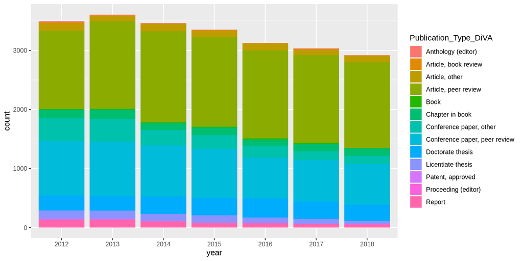

### Web of Science coverage

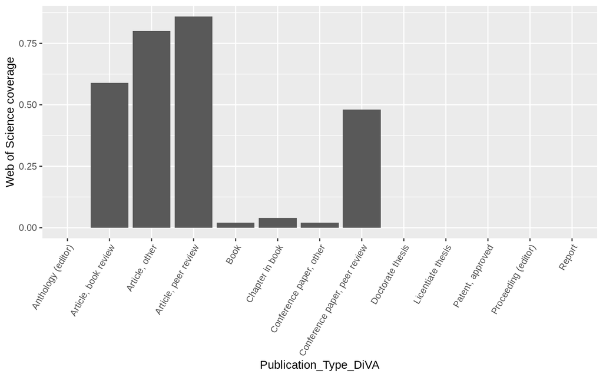

# Citation impact

#### KTH Royal Institute of Technology

### Citations 3-year window

| Publication_Year_ch | P_frac | C3_frac | C3 |
| --- | --- | --- | --- |
| 2012 | 1594.84 | 5501.24 | 3.45 |
| 2013 | 1678.07 | 6724.05 | 4.01 |
| 2014 | 1768.93 | 7510.36 | 4.25 |
| 2015 | 1815.45 | 8524.88 | 4.7 |
| 2016 | 1750.83 | 7323 | 4.18 |
| Total | 8608.13 | 35583.53 | 4.13 |

### Field normalized citations - Fractionalized (3-year moving average)

| interval | P_frac | cf | top10_count | top10_share |
| --- | --- | --- | --- | --- |
| 2012-2014 | 3722.56 | 1.15 | 437.45 | 0.12 |
| 2013-2015 | 3903.08 | 1.19 | 464.53 | 0.12 |
| 2014-2016 | 3920.3 | 1.13 | 429.52 | 0.11 |
| 2015-2017 | 3802.05 | 1.13 | 416.75 | 0.11 |
| Total | 7524.6 | 1.14 | 854.2 | 0.11 |

### Average field normalized citation indicator

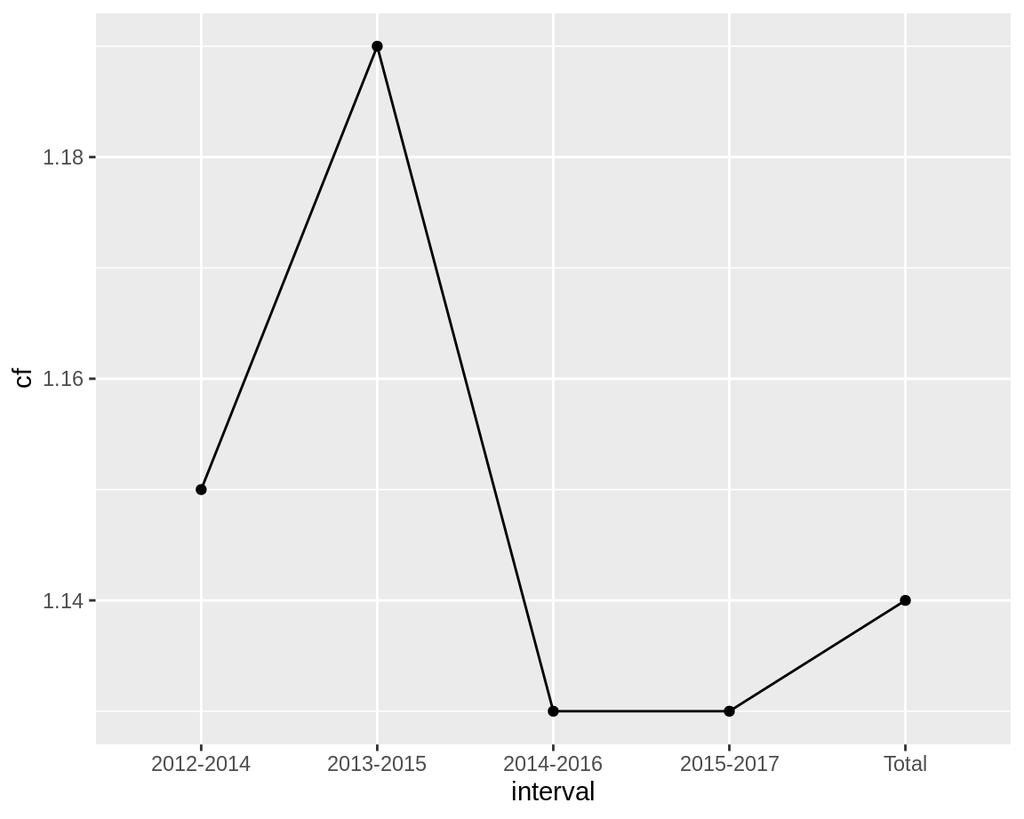

### %Top-10%

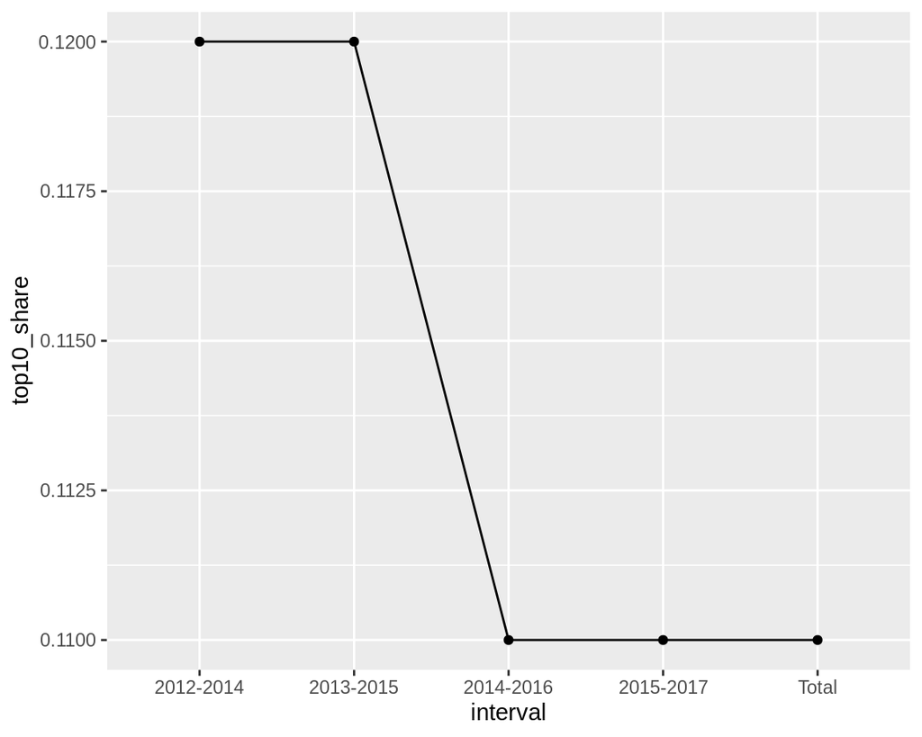

# Journal impact

#### KTH Royal Institute of Technology

### 3-year moving average

| interval | P_frac | jcf | top20_count | top20_share |
| --- | --- | --- | --- | --- |
| 2012-2014 | 3723.39 | 1.27 | 1143.72 | 0.31 |
| 2013-2015 | 3904.2 | 1.27 | 1202.93 | 0.31 |
| 2014-2016 | 3925.46 | 1.26 | 1205.21 | 0.31 |
| 2015-2017 | 3813.6 | 1.25 | 1158.97 | 0.3 |
| 2016-2018 | 3716.18 | 1.26 | 1154.17 | 0.31 |
| Total | 8760.39 | 1.26 | 2701.52 | 0.31 |

### Field normalized journal indicator

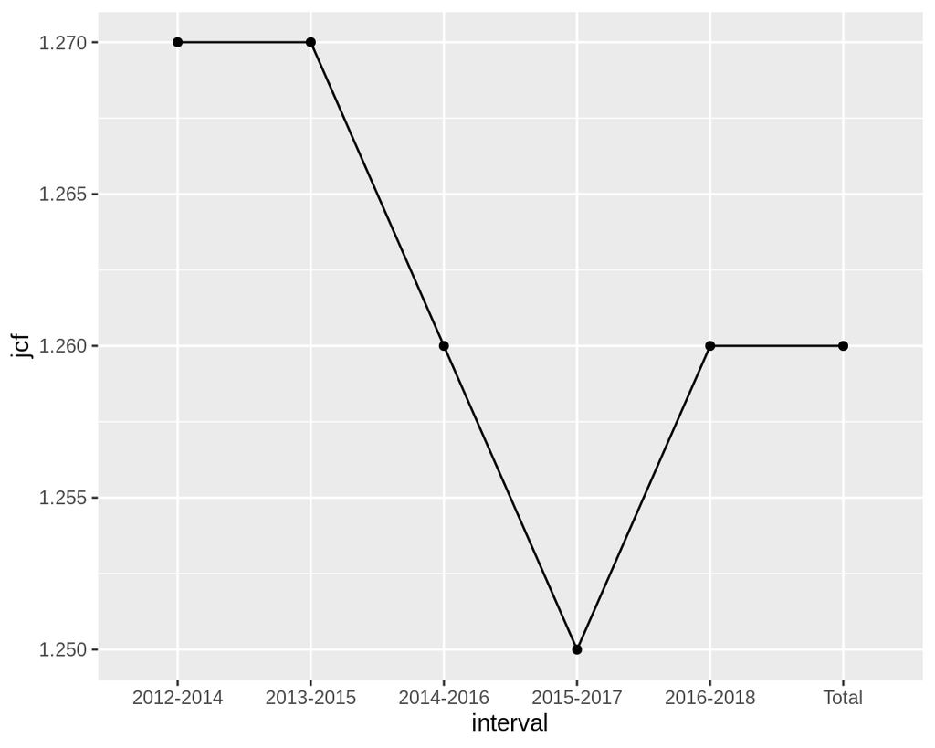

### Journal Top-20%

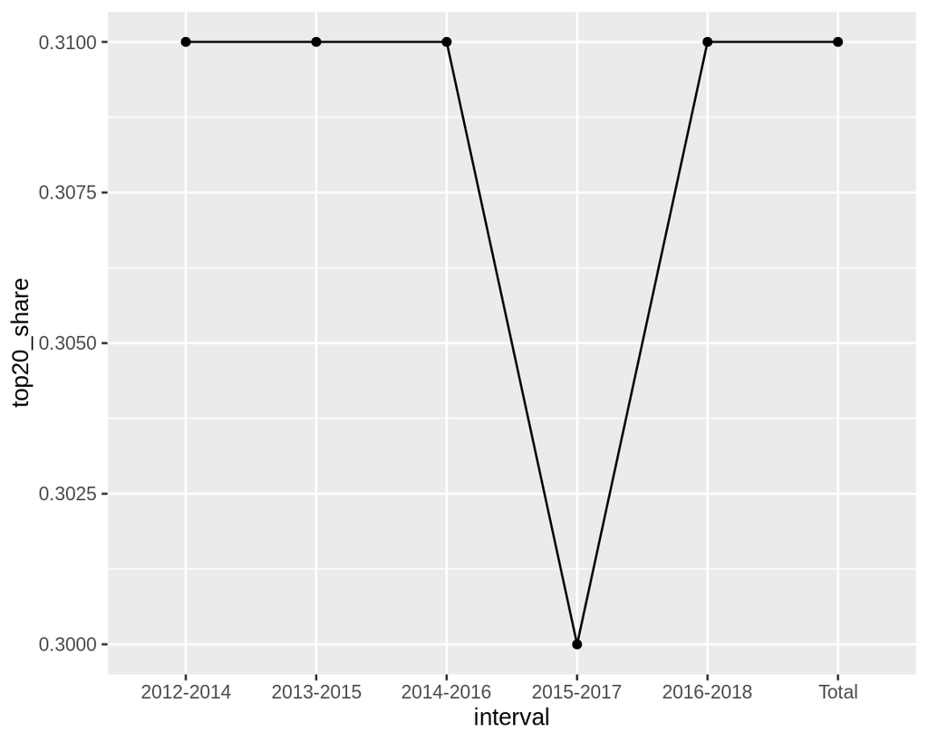

# Co-publishing

#### KTH Royal Institute of Technology

### Internationally and with Swedish non-university organizations (3-year moving average)

| interval | P_full | nonuniv_count | nonuniv_share | int_count | int_share |
| --- | --- | --- | --- | --- | --- |
| 2012-2014 | 6812 | 1111 | 0.16 | 4179 | 0.61 |
| 2013-2015 | 7276 | 1285 | 0.18 | 4644 | 0.64 |
| 2014-2016 | 7627 | 1381 | 0.18 | 5075 | 0.67 |
| 2015-2017 | 7808 | 1482 | 0.19 | 5408 | 0.69 |
| 2016-2018 | 7932 | 1552 | 0.2 | 5603 | 0.71 |
| Total | 17303 | 3124 | 0.18 | 11494 | 0.66 |

### Graphs

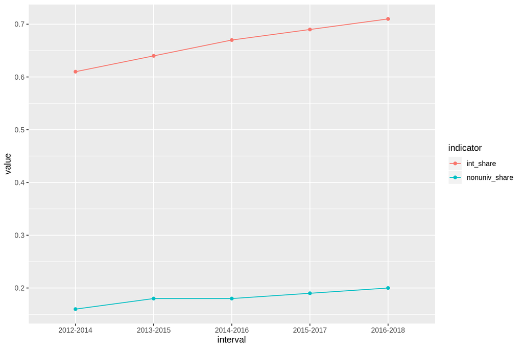